# Easy Credit

Jackson Whitehair

2018-08-06

[figure not shown]

# 1 Financial Deregulation

## 1.1 Mortgage Finance to GDP Ratio

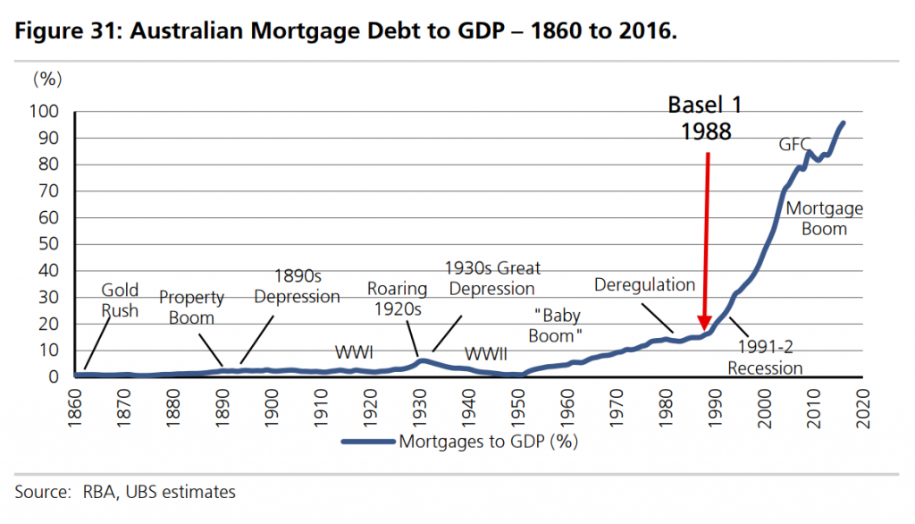

*UBS Survey of recent mortgage holders* - [UBS 13/09/2017](http://www.austmm.com/2017/09/13/ubs-survey-of-recent-mortgage-holders/)

## 1.2 Net Interest Margins

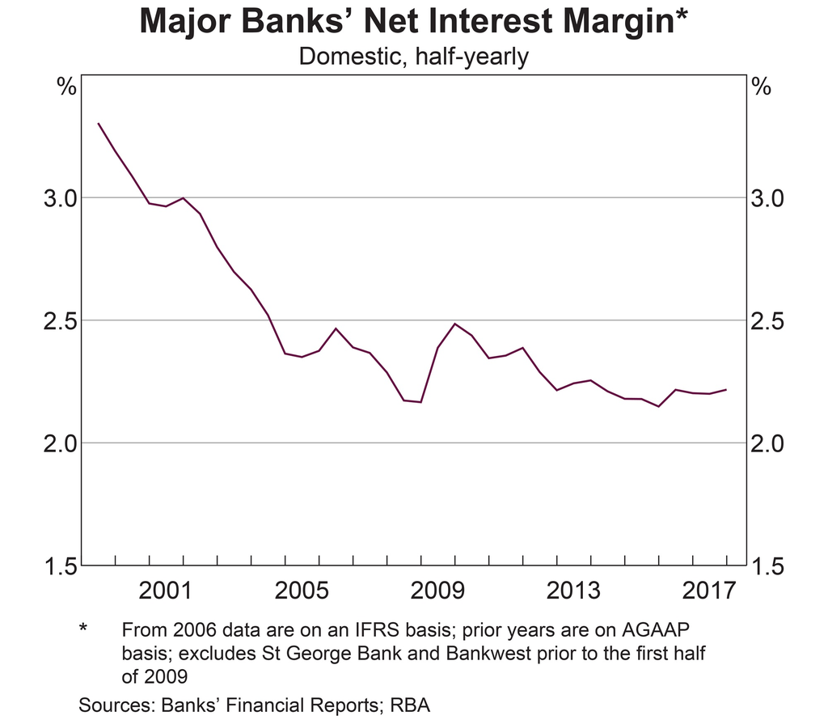

RBA Chart Pack [Banking Indicators 28/6/2018](https://www.rba.gov.au/chart-pack/banking-indicators.html)

# 2 Larger Loan Amounts

## 2.1 Loan to Income Ratios

## 2.2 Parental Assistance

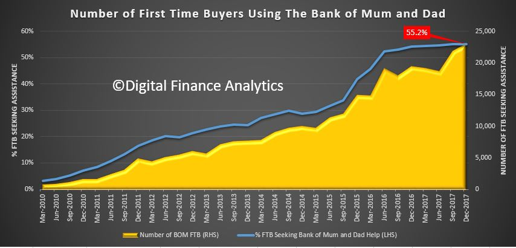

*Bank of Mum and Dad Now A “Top 10” Lender* - Digital Finance Analytics [17/1/2018](http://digitalfinanceanalytics.com/blog/tag/bank-of-mum-and-dad/)

## 2.3 Major Bank Lending for Interest-Only Loans

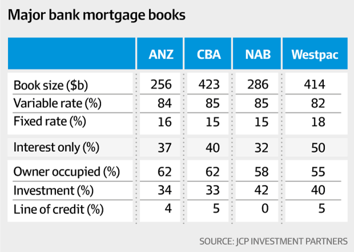

*Interest-only loans could be ‘Australia’s sub-prime’* - [AFR 19/05/2017](http://www.afr.com/business/banking-and-finance/interestonly-loans-could-be-australias-subprime-20170519-gw939m)

## 2.4 Type of Borrower

### 2.4.1 Owner-Occupier vs Investor

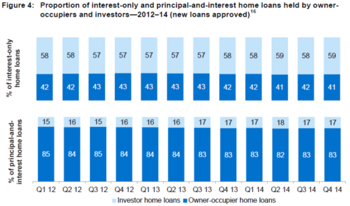

*Review of interest-only home loans* - [ASIC August 2015](http://asic.gov.au/about-asic/media-centre/find-a-media-release/2015-releases/15-220mr-lenders-to-improve-standards-following-interest-only-loan-review/)

### 2.4.2 Types of Investors

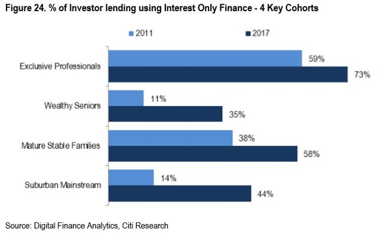

*This housing expert thinks Australian investors may be heading towards the ‘cliff edge’ on loan repayments* - Business Insider [Citi 13/10/2017](https://www.businessinsider.com.au/this-housing-expert-thinks-australian-investors-may-be-heading-towards-the-cliff-edge-on-loan-repayments-2017-10)

## 2.5 Interest-Only Loan Cliff

## 2.6 Proportion Converting

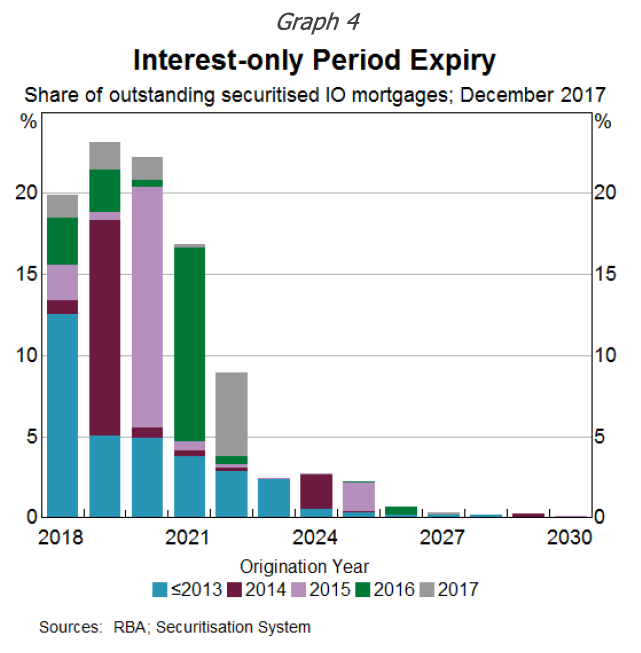

*The Limits of Interest-Only Lending* - Christopher Kent Address to the Housing Industry Association Breakfast, Reserve Bank of Australia, [RBA 24/04/2018](http://www.rba.gov.au/speeches/2018/sp-ag-2018-04-24.html)

### 2.6.1 Amount Converting to Principal and Interest

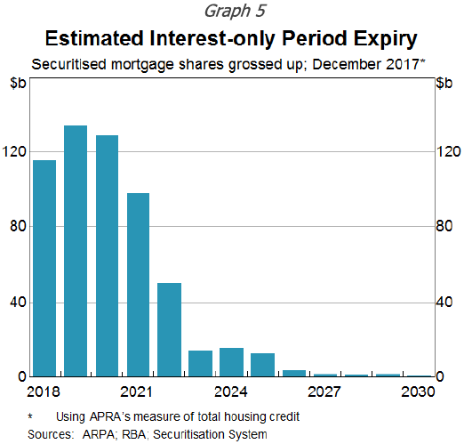

*The Limits of Interest-Only Lending* - Christopher Kent Address to the Housing Industry Association Breakfast, Reserve Bank of Australia, [RBA 24/04/2018](http://www.rba.gov.au/speeches/2018/sp-ag-2018-04-24.html)

# 3 Loose Lending Practices

## 3.1 UBS Research on Liar Loans

### 3.1.1 Mortgage Applications Not Factually Accurate

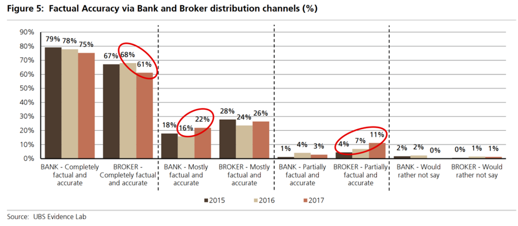

*UBS Survey of recent mortgage holders* - [UBS 13/09/2017](http://www.austmm.com/2017/09/13/ubs-survey-of-recent-mortgage-holders/)

### 3.1.2 Magnitude of Factual Inaccuracy

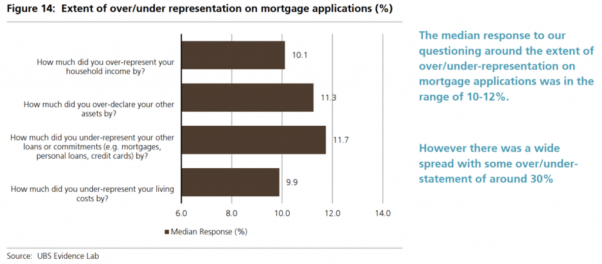

*UBS Survey of recent mortgage holders* - [UBS 13/09/2017](http://www.austmm.com/2017/09/13/ubs-survey-of-recent-mortgage-holders/)

## 3.2 Westpac Mortgage Data Release 2018

*Royal Commission: Westpac mortgage book riskier than peers* by Elizabeth Fry - [RFi Group 26/04/2018](https://www.rfigroup.com/rfi-group/news/royal-commission-westpac-mortgage-book-riskier-peers)

*Westpac Banking Corporation APRA Targeted Review of data used in residential mortgage serviceability assessments* - [PWC Report May 2017](https://financialservices.royalcommission.gov.au/public-hearings/Documents/exhibits-2018/23-march/EXHIBIT-1-190.pdf)

# 4 Repayment Stability

## 4.1 Arrears Rates

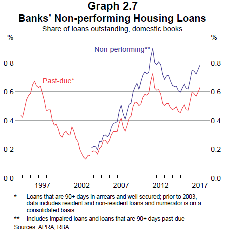

*Financial Stability Review 2017, Section 2. Household and Business Finances* - [RBA October 2017](http://www.rba.gov.au/publications/fsr/2017/oct/)

## 4.2 Applications for Property Possessions

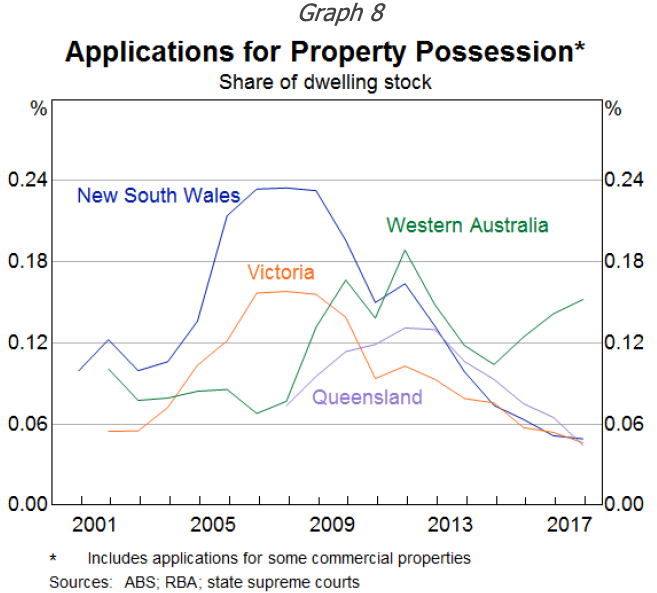

*Household Indebtedness and Mortgage Stress* - Michele Bullock Address to the Responsible Lending and Borrowing Summit [RBA 20/2/2018](https://www.rba.gov.au/speeches/2018/sp-ag-2018-02-20.html)

## 4.3 Repayment Buffers

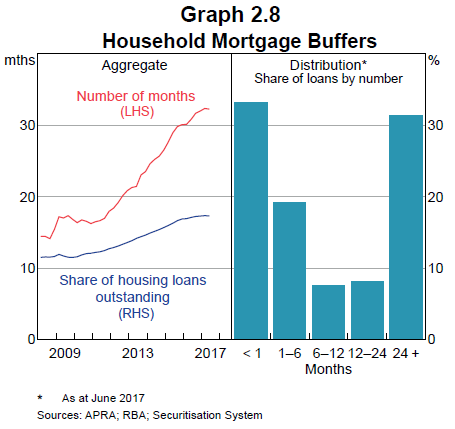

*Financial Stability Review 2017, Section 2. Household and Business Finances* - [RBA October 2017](http://www.rba.gov.au/publications/fsr/2017/oct/)